# Reproducible templates

09/11/2020

## About the course

This is the final project of the Coursera course [Reproducible templates for analysis and dissemiation](https://www.coursera.org/learn/reproducible-templates-analysis/). Here I will show some of the skills that I have developed during the course.

I am particularly excited because thanks to the course, I started preparing all my reports in R Markdown.

## Skills

**To produce pdf and html documents**

- Customize the text and headers, bold, italics, etc
- Work with templates
- Enter plots, tables, code chunks and images
- Keep a workflow with version control using git and github
- Manage references and bibliography styles

## A plot of the `pressure` dataset

I have used the ggplot system to create a plot

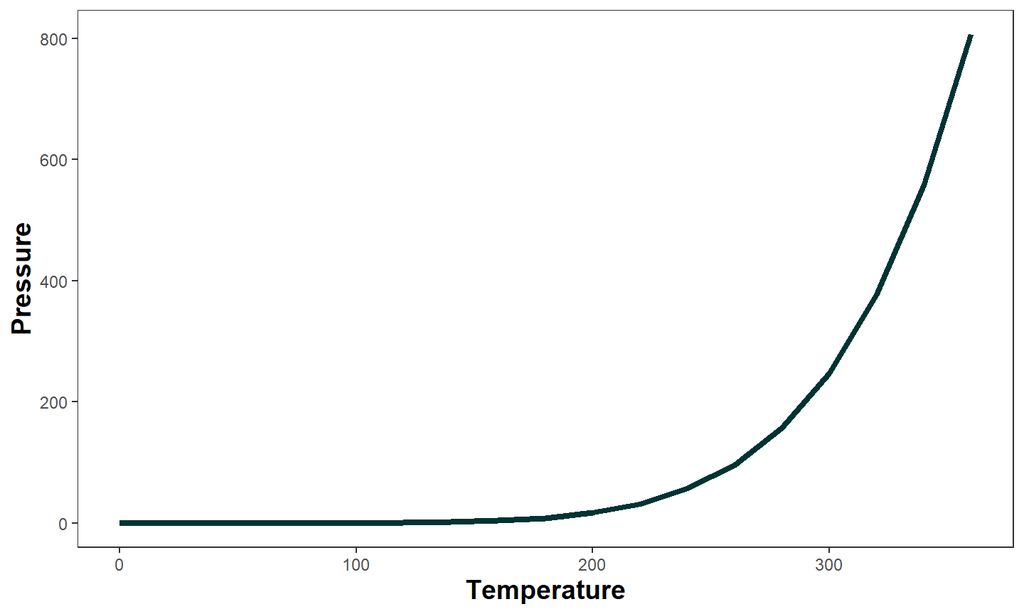

## A table

This is an example of a table made with the `knitr::kable()` function

| SPEED | DISTANCE |
| --- | --- |
| 4 | 2 |
| 4 | 10 |
| 7 | 4 |
| 7 | 22 |
| 8 | 16 |
| 9 | 10 |

## Some tools

Mani of the customizations of this presentations were made using a css style document. For example:

```
slides > slide.title-slide hgroup h1 {
    color: #003333;
}

slides > slide.title-slide p {
  color: #1f2023;
}

slides > slide.title-slide hgroup h2 {
  color: #1f2023;
}
```

I have used this code to change the colors of the title, subtitle and text of the first slide.

## Source

Thank you very much!

I really recommend to take the Course of Reproducible templates.

If you want to see the codes to generate this presentation, please visit my [github page](https://github.com/gflorezm/FinalProject).